# 第9课 回归分析之一 答案

顶刊研习社

Li Zongzhang

2023-10-29

```r
library(boot)
library(tidyverse)
library(survival)
library(survminer)
library(gt)
library(gtsummary)
```

# 1 习题1

数据文件：R自带数据mtcars

1.1 以mpg为被解释变量，建立若干个一元回归模型，解释变量为数据框mtcars中除了mpg之外的其余的变量。在同一张表格中报告这些一元回归模型的估计结果。

```r
data(mtcars)
library(gtsummary)
library(gt)

mtcars %>%
  tbl_uvregression(
    method = lm,
    y = mpg
  )
```

| **Characteristic** | **N** | **Beta** | **95% CI**<sup>1</sup> | **p-value** |
| --- | --- | --- | --- | --- |
| cyl | 32 | -2.9 | -3.5, -2.2 | <0.001 |
| disp | 32 | -0.04 | -0.05, -0.03 | <0.001 |
| hp | 32 | -0.07 | -0.09, -0.05 | <0.001 |
| drat | 32 | 7.7 | 4.6, 11 | <0.001 |
| wt | 32 | -5.3 | -6.5, -4.2 | <0.001 |
| qsec | 32 | 1.4 | 0.27, 2.6 | 0.017 |
| vs | 32 | 7.9 | 4.6, 11 | <0.001 |
| am | 32 | 7.2 | 3.6, 11 | <0.001 |
| gear | 32 | 3.9 | 1.3, 6.6 | 0.005 |
| carb | 32 | -2.1 | -3.2, -0.89 | 0.001 |

<sup>1</sup> CI = Confidence Interval

1.2 以mpg为被解释变量, 选取适当的解释变量，做一元回归、二元回归、三元回归，在同一张表格中报告这3个模型的估计结果。

```r
m1 <- mtcars %>% lm(mpg ~ wt, .) %>%
  tbl_regression(
    estimate_fun = ~ style_number(.x, digits = 3),
    pvalue_fun = ~ style_pvalue(.x, digits = 3)
  ) %>%
  add_significance_stars(hide_p = FALSE,
                         thresholds = c(0.01, 0.05, 0.10),) %>%
  bold_p(t = 0.10) %>%
  add_glance_table(
    include = c(nobs, adj.r.squared, p.value)
  )

m2 <- mtcars %>% lm(mpg ~ wt + disp, .) %>%
  tbl_regression(
    estimate_fun = ~ style_number(.x, digits = 3),
    pvalue_fun = ~ style_pvalue(.x, digits = 3)
  ) %>%
  add_significance_stars(hide_p = FALSE,
                         thresholds = c(0.01, 0.05, 0.10),) %>%
  bold_p(t = 0.10) %>%
  add_glance_table(
    include = c(nobs, adj.r.squared, p.value)
  )

m3 <- mtcars %>% lm(mpg ~ wt + disp + cyl, .) %>%
  tbl_regression(
    estimate_fun = ~ style_number(.x, digits = 3),
    pvalue_fun = ~ style_pvalue(.x, digits = 3)
  ) %>%
  add_significance_stars(hide_p = FALSE,
                         thresholds = c(0.01, 0.05, 0.10),) %>%
  bold_p(t = 0.10) %>%
  add_glance_table(
    include = c(nobs, adj.r.squared, p.value)
  )

tbl_merge(list(m1, m2, m3),
          tab_spanner = c("**Model 1**", "**Model 2**", "**Model 3**")) %>%
  bold_labels() %>%
  italicize_levels()
```

| **Characteristic** | **Model 1** **Beta**<sup>1</sup> | **Model 1** **SE**<sup>2</sup> | **Model 1** **p-value** | **Model 2** **Beta**<sup>1</sup> | **Model 2** **SE**<sup>2</sup> | **Model 2** **p-value** | **Model 3** **Beta**<sup>1</sup> | **Model 3** **SE**<sup>2</sup> | **Model 3** **p-value** |
| --- | --- | --- | --- | --- | --- | --- | --- | --- | --- |
| wt | -5.344*** | 0.559 | <0.001 | -3.351*** | 1.16 | 0.007 | -3.636*** | 1.04 | 0.002 |
| No. Obs. | 32 |  |  | 32 |  |  | 32 |  |  |
| Adjusted R² | 0.745 |  |  | 0.766 |  |  | 0.815 |  |  |
| p-value | <0.001 |  |  | <0.001 |  |  | <0.001 |  |  |
| disp |  |  |  | -0.018* | 0.009 | 0.064 | 0.007 | 0.012 | 0.533 |
| cyl |  |  |  |  |  |  | -1.785*** | 0.607 | 0.007 |

<sup>1</sup> *p<0.1; **p<0.05; ***p<0.01  
<sup>2</sup> SE = Standard Error

1.3 并用anova()函数对上述三个模型进行比较。

```r
model1 <- mtcars %>% lm(mpg ~ wt, .)

model2 <- mtcars %>% lm(mpg ~ wt + disp, .)

model3 <- mtcars %>% lm(mpg ~ wt + disp + cyl, .)

anova(model1, model2)
```

```
Analysis of Variance Table

Model 1: mpg ~ wt
Model 2: mpg ~ wt + disp
  Res.Df    RSS Df Sum of Sq      F  Pr(>F)
1     30 278.32
2     29 246.68  1    31.639 3.7195 0.06362 .
---
Signif. codes:  0 '***' 0.001 '**' 0.01 '*' 0.05 '.' 0.1 ' ' 1
```

```r
anova(model1, model3)
```

```
Analysis of Variance Table

Model 1: mpg ~ wt
Model 2: mpg ~ wt + disp + cyl
  Res.Df    RSS Df Sum of Sq     F  Pr(>F)
1     30 278.32
2     28 188.49  2     89.83 6.672 0.00427 **
---
Signif. codes:  0 '***' 0.001 '**' 0.01 '*' 0.05 '.' 0.1 ' ' 1
```

```r
anova(model2, model3)
```

```
Analysis of Variance Table

Model 1: mpg ~ wt + disp
Model 2: mpg ~ wt + disp + cyl
  Res.Df    RSS Df Sum of Sq     F   Pr(>F)
1     29 246.68
2     28 188.49  1     58.19 8.644 0.006512 **
---
Signif. codes:  0 '***' 0.001 '**' 0.01 '*' 0.05 '.' 0.1 ' ' 1
```

1.4 以mpg为被解释变量, 选取适当的解释变量，构建一个多元回归模型，该模型中需要有一个交互项，以表格形式报告该模型的估计结果，并在表中列出模型的校正的R平方，给显著的系数标记上星号。

```r
 mtcars %>% lm(mpg ~ wt + disp + cyl + disp:cyl, .) %>%
  tbl_regression(
    estimate_fun = ~ style_number(.x, digits = 3),
    pvalue_fun = ~ style_pvalue(.x, digits = 3)
  ) %>%
  add_significance_stars(hide_p = FALSE,
                         thresholds = c(0.01, 0.05, 0.10),) %>%
  bold_p(t = 0.10) %>%
  add_glance_table(
    include = c(nobs, adj.r.squared, p.value)
  )
```

| **Characteristic** | **Beta**<sup>1</sup> | **SE**<sup>2</sup> | **p-value** |
| --- | --- | --- | --- |
| wt | -2.737** | 1.05 | 0.014 |
| disp | -0.087* | 0.043 | 0.053 |
| cyl | -3.005*** | 0.780 | <0.001 |
| disp * cyl | 0.011** | 0.005 | 0.031 |
| No. Obs. | 32 |  |  |
| Adjusted R² | 0.839 |  |  |
| p-value | <0.001 |  |  |

<sup>1</sup> *p<0.1; **p<0.05; ***p<0.01  
<sup>2</sup> SE = Standard Error

1.5 用图形呈现1.4中估计的回归模型解释变量的Y的影响效应、解释变量系数的置信区间，并诊断该模型是否满足线性模型的假定？

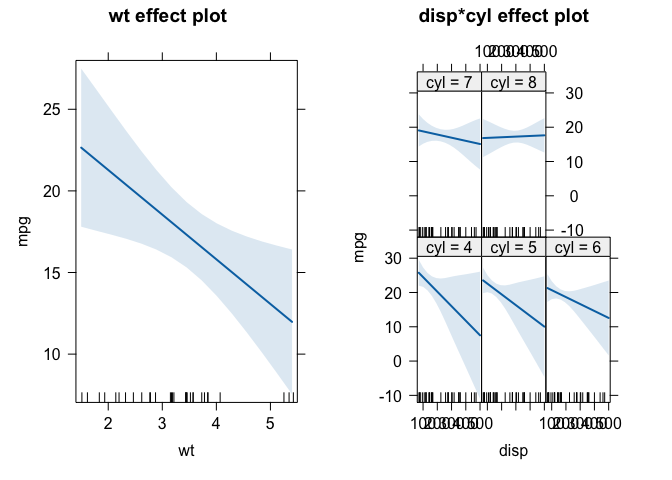

```r
library(effects)
mtcars %>% lm(mpg ~ wt + disp + cyl + disp:cyl, .) %>%
  allEffects() %>%
  plot()
```

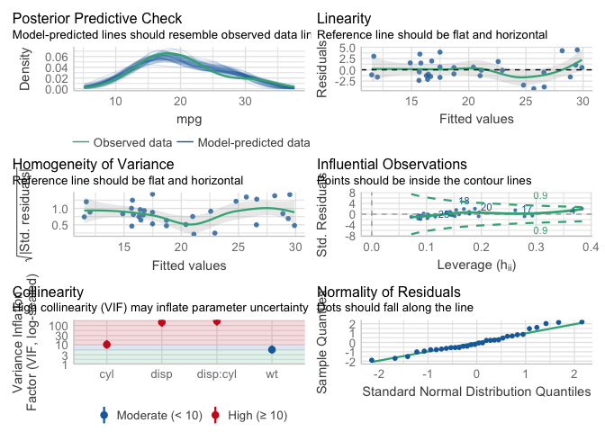

```r
library(performance)
mtcars %>% lm(mpg ~ wt + disp + cyl + disp:cyl, .)  %>%
  performance::check_model()
```

# 2 习题2

数据文件：load(“lbw.rda”)

[数据文件下载](https://pan.baidu.com/s/13Kv8qLdUs-J0l8FRK5qCvg?pwd=1234)

2.1 将数据集lbw中的变量名全部转换为小写字母，并将数据集lbw复制给对象df，将df中的列id, 列bwt删除.

```r
# 导入数据文件lbw.rda，该文件放置在项目所在的同一路径下。
# 若数据文lbw.rda没有放在与项目同一路径，需要在load()中指定数据文件的路径。
load("lbw.rda")
names(lbw) <- tolower(names(lbw))
df <- lbw
names(df) <- tolower(names(lbw))
df <- df %>% subset(select = -c(id, bwt))
```

2.2 对df中的变量进行转换：将ptl中等于2或3的组别，都合并到ptl等于1的组别中。将ftv中等于3，4，5，6的组别，都合并到ftv = 2的组别中。将low中等于”BWT <= 2500g”的组别，都转换为1，其余组别转换为0。

```r
df$ptl <- ifelse(df$ptl == 2 | df$ptl == 3, 1, df$ptl) %>%
  as.factor()

df$ftv <- ifelse(df$ftv == 3 | df$ftv == 4 |
                   df$ftv == 5| df$ftv == 6,
                 2,
                 df$ftv) %>%
    as.factor()

df$low <- ifelse(df$low == "BWT <= 2500g", 1, 0)
```

2.3 以table1的形式报告df中各变量的描述性统计。

```r
df %>% tbl_summary()
```

| **Characteristic** | **N = 189**<sup>1</sup> |
| --- | --- |
| low | 59 (31%) |
| age | 23 (19, 26) |
| lwt | 121 (110, 140) |
| race |  |
| white | 96 (51%) |
| black | 26 (14%) |
| other | 67 (35%) |
| smoke | 74 (39%) |
| ptl |  |
| 0 | 159 (84%) |
| 1 | 30 (16%) |
| ht | 12 (6.3%) |
| ui | 28 (15%) |
| ftv |  |
| 0 | 100 (53%) |
| 1 | 47 (25%) |
| 2 | 42 (22%) |

<sup>1</sup> n (%); Median (IQR)

2.4 建立若干个一元logistic回归模型，以low为因变量，age，lwt，race，smoke，ptl，ht，ui，ftv分别为自变量，以表格的形式。报告这些一元logistic回归的估计结果。

```r
df %>%
  gtsummary::tbl_uvregression(
    method = glm,
    y = low,
    method.args = list(family = binomial),
    exponentiate = FALSE
  )
```

| **Characteristic** | **N** | **log(OR)**<sup>1</sup> | **95% CI**<sup>1</sup> | **p-value** |
| --- | --- | --- | --- | --- |
| age | 189 | -0.05 | -0.12, 0.01 | 0.10 |
| lwt | 189 | -0.01 | -0.03, 0.00 | 0.023 |
| race | 189 |  |  |  |
| white |  | — | — |  |
| black |  | 0.84 | -0.08, 1.8 | 0.068 |
| other |  | 0.64 | -0.04, 1.3 | 0.067 |
| smoke | 189 |  |  |  |
| no |  | — | — |  |
| yes |  | 0.70 | 0.08, 1.3 | 0.028 |
| ptl | 189 |  |  |  |
| 0 |  | — | — |  |
| 1 |  | 1.5 | 0.66, 2.3 | <0.001 |
| ht | 189 |  |  |  |
| no |  | — | — |  |
| yes |  | 1.2 | 0.03, 2.5 | 0.046 |
| ui | 189 |  |  |  |
| no |  | — | — |  |
| yes |  | 0.95 | 0.13, 1.8 | 0.023 |
| ftv | 189 |  |  |  |
| 0 |  | — | — |  |
| 1 |  | -0.61 | -1.4, 0.16 | 0.13 |
| 2 |  | -0.34 | -1.2, 0.43 | 0.4 |

<sup>1</sup> OR = Odds Ratio, CI = Confidence Interval

```r
df %>%
  gtsummary::tbl_uvregression(
    method = glm,
    y = low,
    method.args = list(family = binomial),
    exponentiate = TRUE
  )
```

| **Characteristic** | **N** | **OR**<sup>1</sup> | **95% CI**<sup>1</sup> | **p-value** |
| --- | --- | --- | --- | --- |
| age | 189 | 0.95 | 0.89, 1.01 | 0.10 |
| lwt | 189 | 0.99 | 0.97, 1.00 | 0.023 |
| race | 189 |  |  |  |
| white |  | — | — |  |
| black |  | 2.33 | 0.93, 5.77 | 0.068 |
| other |  | 1.89 | 0.96, 3.76 | 0.067 |
| smoke | 189 |  |  |  |
| no |  | — | — |  |
| yes |  | 2.02 | 1.08, 3.80 | 0.028 |
| ptl | 189 |  |  |  |
| 0 |  | — | — |  |
| 1 |  | 4.32 | 1.94, 9.95 | <0.001 |
| ht | 189 |  |  |  |
| no |  | — | — |  |
| yes |  | 3.37 | 1.03, 11.8 | 0.046 |
| ui | 189 |  |  |  |
| no |  | — | — |  |
| yes |  | 2.58 | 1.13, 5.88 | 0.023 |
| ftv | 189 |  |  |  |
| 0 |  | — | — |  |
| 1 |  | 0.54 | 0.24, 1.17 | 0.13 |
| 2 |  | 0.71 | 0.32, 1.53 | 0.4 |

<sup>1</sup> OR = Odds Ratio, CI = Confidence Interval

2.5 建立多元logistic回归模型，解释变量包括age, lwt, smoke, ui, ptl，ht, ftv, 以及race. 以表格的形式报告多元logistic回归的估计结果。

```r
glm(low ~ age + lwt+ smoke + ui + ptl + ht + ftv + race,
                 df, family = "binomial") %>% tbl_regression(exponentiate = TRUE,  #被解释变量odds ratio
              estimate_fun = ~ style_number(.x, digits = 3),
              pvalue_fun = ~ style_pvalue(.x, digits = 3))
```

| **Characteristic** | **OR**<sup>1</sup> | **95% CI**<sup>1</sup> | **p-value** |
| --- | --- | --- | --- |
| age | 0.963 | 0.891, 1.038 | 0.336 |
| lwt | 0.984 | 0.970, 0.998 | 0.027 |
| smoke |  |  |  |
| no | — | — |  |
| yes | 2.129 | 0.930, 4.975 | 0.075 |
| ui |  |  |  |
| no | — | — |  |
| yes | 1.974 | 0.785, 4.914 | 0.143 |
| ptl |  |  |  |
| 0 | — | — |  |
| 1 | 3.833 | 1.517, 10.129 | 0.005 |
| ht |  |  |  |
| no | — | — |  |
| yes | 6.775 | 1.715, 30.447 | 0.008 |
| ftv |  |  |  |
| 0 | — | — |  |
| 1 | 0.646 | 0.244, 1.621 | 0.363 |
| 2 | 1.196 | 0.482, 2.920 | 0.695 |
| race |  |  |  |
| white | — | — |  |
| black | 3.295 | 1.154, 9.600 | 0.026 |
| other | 2.097 | 0.855, 5.281 | 0.109 |

<sup>1</sup> OR = Odds Ratio, CI = Confidence Interval

2.6 建立两个logistic回归模型，模型2的解释变量包括age, lwt, smoke, ui, ptl，ht, ftv, 以及race, 模型1的解释变量包括age, lwt, smoke, ui, ptl, 比较这两个模型。

```r
model1 <- glm(low ~ age + lwt+ smoke + ui + ptl + ht + ftv + race,
                 df, family = "binomial")

model2 <- glm(low ~ age + lwt+ smoke + ui + ptl,
                 df, family = "binomial")

anova(model2, model1, test = "Chisq")
```

```
Analysis of Deviance Table

Model 1: low ~ age + lwt + smoke + ui + ptl
Model 2: low ~ age + lwt + smoke + ui + ptl + ht + ftv + race
  Resid. Df Resid. Dev Df Deviance Pr(>Chi)
1       183     210.72
2       178     195.48  5   15.244  0.00937 **
---
Signif. codes:  0 '***' 0.001 '**' 0.01 '*' 0.05 '.' 0.1 ' ' 1
```

2.7 用图形呈现2.5中logistic多元回归模型解释变量系数的置信区间。

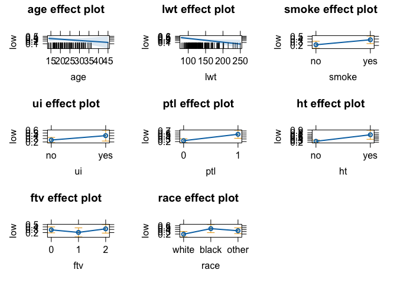

```r
glm(low ~ age + lwt+ smoke + ui + ptl + ht + ftv + race,
                 df, family = "binomial") %>%
  effects::allEffects() %>%
  plot()
```

2.8 计算2.5中logistic多元回归模型在样本均值点的平均边际效应。

```r
mfx::logitmfx(low ~ age + lwt+ smoke + ui + ptl + ht + ftv + race,
                 df)
```

```
Call:
mfx::logitmfx(formula = low ~ age + lwt + smoke + ui + ptl +
    ht + ftv + race, data = df)

Marginal Effects:
               dF/dx  Std. Err.       z    P>|z|
age       -0.0073713  0.0076081 -0.9689 0.332612
lwt       -0.0030988  0.0013817 -2.2428 0.024909 *
smokeyes   0.1542049  0.0875802  1.7607 0.078285 .
uiyes      0.1475577  0.1076834  1.3703 0.170595
ptl1       0.3045239  0.1136779  2.6788 0.007388 **
htyes      0.4428752  0.1519895  2.9139 0.003570 **
ftv1      -0.0818986  0.0849246 -0.9644 0.334861
ftv2       0.0362232  0.0941498  0.3847 0.700430
raceblack  0.2701769  0.1272684  2.1229 0.033763 *
raceother  0.1528024  0.0972130  1.5718 0.115990
---
Signif. codes:  0 '***' 0.001 '**' 0.01 '*' 0.05 '.' 0.1 ' ' 1

dF/dx is for discrete change for the following variables:

[1] "smokeyes"  "uiyes"     "ptl1"      "htyes"     "ftv1"      "ftv2"
[7] "raceblack" "raceother"
```